# The_Nameless_S_Mobile_Write_Up

Jake Cepela, Qiuyi Lu, Zhengyu Jiang, Xi Jiang

3/4/2020

##### 1. Develop a model to predict customer churn

We developed logistic regression and nn model. Both are used with weight to train the model. When looking at how to build a logistic regression, we must first analyze the different variables to look for outliers, interactions, and variables not significant to the regression. In our analysis, we looked at interactions with region and revenue, occupation and revenue, occupation and change in revenue, region and change in revenue, occupation and change in minutes, and region and change in minutes.

Although we explored these different interactions, the model we felt was best used no interactions. This was due to the increase in AUC being minimal compared to our base model. When looking to increase the model, further interactions and variables should have a noticeable increase to warrant the additional complexity. Further, we used all variables except for cars and conference. We removed conference and cars since the variables were not statistically significant to the model. The best AUC we were able to achieve within reasonable change was 69.44%

First, the Variable Importance Plot:

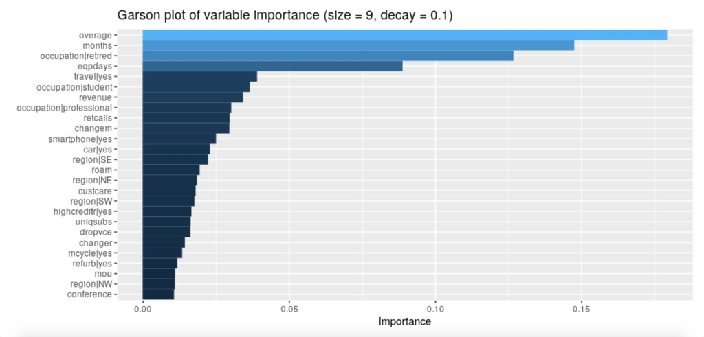

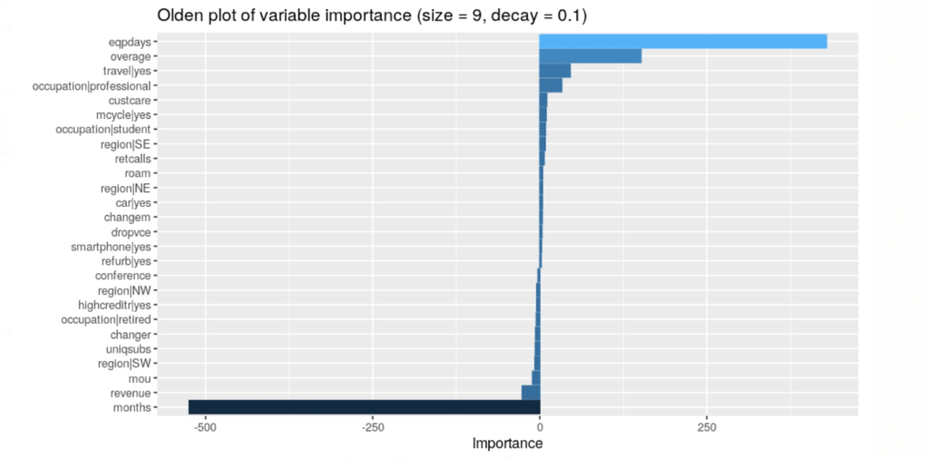

##### 2. Use the model output from a logistic regression to understand the main drivers of churn and report on the key factors that predict customer churn and their relative importance.

Looking at the output for the logistic regression, we can notice the importance of variables based on their odds ratio’s.

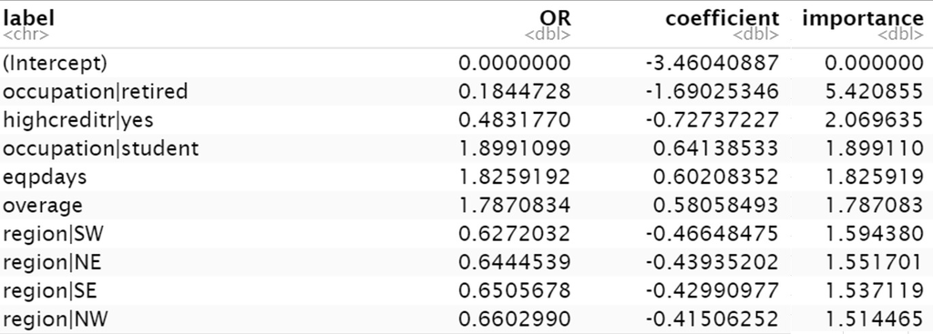

Odds Ratio

Interestingly, the two most important variables, if they are retired and if they have high credit, both suggest that the customer will be less likely to churn, not more. We can determine this by understanding that an Odds Ratio of less than one will have a negative effect, while an Odds Ratio greater than 1 will have a positive effect. The next three, if they are a student, days the customer has had the device, and minutes of overage, will all increase the likelihood that someone churns.

##### 3. Use insights on churn drivers to develop actions/offers/incentives

The insights provided by the Neural Network and the Logistic Regression both determined that the actionable items we would focus on were to decrease days the customer has had the device and the average minutes of overage the customer had in a month. In both instances, overage and eqpdays were the variables that we would act on.

##### 4. Quantify the impact of these actions/offers/incentives on the probability of churn

• Either (i) predict the effect of a churn driver (similar to what we did for Pentathlon III) or (ii) suggest how you might test the action/incentive/offer in the field • Generate predictions for the representative sample

Looking to overage first, we determined to increase the plan for the customers that had overage by giving those customers unlimited minutes to talk. Looking at churn rate, focused solely on this cohort, we see a decrease of churn from 2.4% to 1.4%.

Looking at EQPdays next, our plan was to offer a discount for anyone who had been in the plan for 600 days because it makes more sense that people change their phone after at least 1 year. So the eqpdays over 600 days would be 0. Looking at churn rate, focused solely on this cohort, we see a decrease of churn from 2.5% to 1.4%.

•Since you can’t actually execute a test, describe how you would set up such a test and then make an assumption about the impact on churn that you can use in steps 5 and 6

In order to test these, we would like to do an AB test. We would set the cohorts into two separate groups (for each test). We would make the two groups as identical as possible, then offer the discount or overage plan to each group. From there, we would track the difference the two groups had in churn rate in order to quantify the effect that the action head.

##### 5. Decide which actions/offers/incentives to target to which customers

• For each action/offer/incentive specify the criteria used to select customers. Will you apply the action/offer/incentive to all customers, or a subset? Motivate your approach

For the overage group, we decided to target anyone who had overage greater than 0. We did not subset this cohort, since we determined the cost associated would be minimal relative to the potential gain from the customer. For EQPdays, we also decided to send to everyone who was over 600 days for the same reason. We looked into subsetting the data based on interactions for who would be most likely to accept the offer based on other criteria. However, we were unable to find a meaningful subset of the data in order to better target the cohort.

##### 6. Evaluate the economics: For each action/offer/incentive evaluate the profitability implications using a 5-year (60 month) time window

For our CLV calculations, we assumed the margin was 40% and the discount rate is .8% per month.

Looking to overage first,we calculated the CLV of a customer in that cohort was $747.0801 over 60 months. After we decrease the churn rate to 0.014, the CLV in that cohort increased to $932.0679, which is an increase of $184.9879.

In our calculations, we didn’t increase any additional costs. Instead, we determined that as long as the unlimited plan cost less than $184.9879 per customer in 5 years, that the plan would be worthwhile. If we extrapolate this to the million customers, we project an increase of revenue of $100,288,080, without changing what those customers were charged.

Looking at EQPdays next, our plan was to offer a discount for anyone who had been in the plan for 600 days. The initial CLV is the $438.3785. After the churn rate decreased to 0.014, we project an increase of CLV to $558.4002. The difference of the two clvs is about $120. So we suggest giving a discount of $80 towards a new device. Assuming that 50% accept this offer and scale the proportion of those people in the representative data to the entire 1 million customers,we project a profit increase of $7,535,361.